# Population-level BLUP models vs. plant-level mixed models

Purpose: understand why marginal R-squared values are so low yet significance levels <0.1

Sophie Breitbart

5/5/2022

# Compare BLUPS w/LMMs

These models are testing for the effect of urbanization across the entire gradient (all populations are included).

Urbanization is quantified as distance from the urban center.

## Latex

### Block is random

#### Original linear mixed model

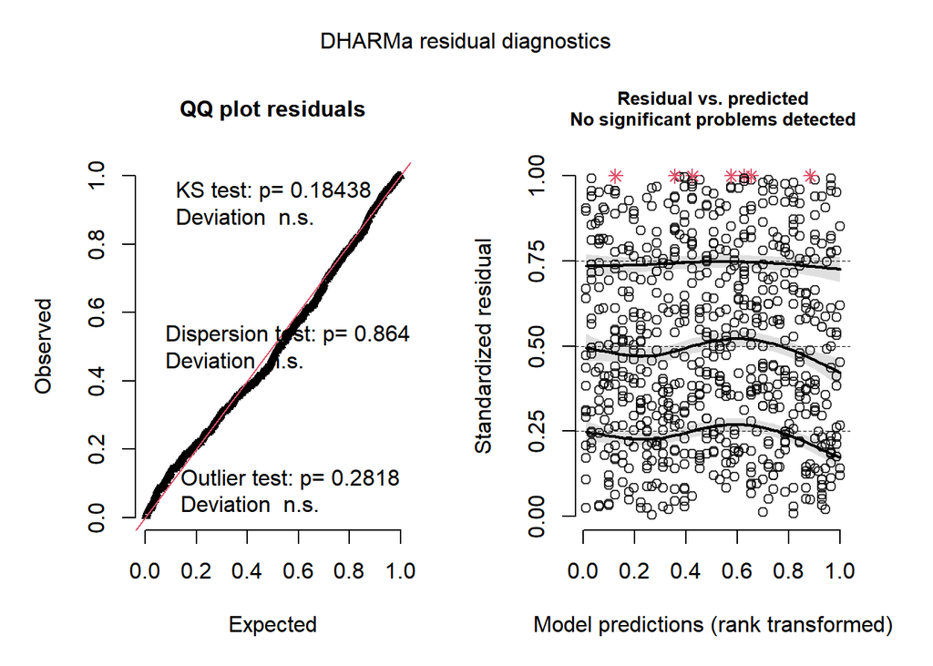

```r
latex_random_LMM <- glmmTMB(sqrt(Latex_weight_mg) ~
                            (1|Block) +
                            (1|Population/Family) +
                            City_dist,
                          data = latex,
                          REML = F)

plot(DHARMa::simulateResiduals(latex_random_LMM))
```

```r
summary(latex_random_LMM)
```

```
##  Family: gaussian  ( identity )
## Formula:
## sqrt(Latex_weight_mg) ~ (1 | Block) + (1 | Population/Family) +      City_dist
## Data: latex
##
##      AIC      BIC   logLik deviance df.resid
##   1774.6   1801.9   -881.3   1762.6      693
##
## Random effects:
##
## Conditional model:
##  Groups            Name        Variance Std.Dev.
##  Block             (Intercept) 0.02296  0.1515
##  Family:Population (Intercept) 0.03876  0.1969
##  Population        (Intercept) 0.02994  0.1730
##  Residual                      0.66510  0.8155
## Number of obs: 699, groups:  Block, 4; Family:Population, 197; Population, 51
##
## Dispersion estimate for gaussian family (sigma^2): 0.665
##
## Conditional model:
##              Estimate Std. Error z value Pr(>|z|)
## (Intercept)  2.722869   0.114050  23.874   <2e-16 ***
## City_dist   -0.001299   0.002614  -0.497    0.619
## ---
## Signif. codes:  0 '***' 0.001 '**' 0.01 '*' 0.05 '.' 0.1 ' ' 1
```

```r
car::Anova(latex_random_LMM) # p = 0.62
```

```
## Analysis of Deviance Table (Type II Wald chisquare tests)
##
## Response: sqrt(Latex_weight_mg)
##            Chisq Df Pr(>Chisq)
## City_dist 0.2469  1     0.6192
```

```r
r.squaredGLMM(latex_random_LMM) # very small R-squared: R2m = 0.0005
```

```
##               R2m       R2c
## [1,] 0.0005906562 0.1216338
```

#### BLUP model

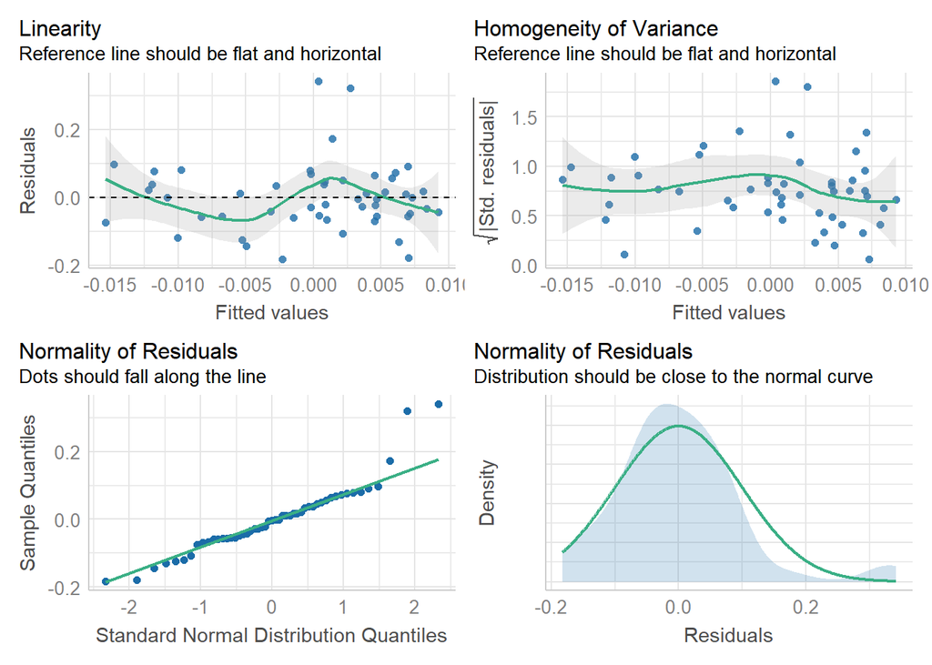

```r
latex_random_LMM_without_citydist <- update(
  latex_random_LMM,
  .~. - City_dist
)

blup_fams_latex_rand <- ranef(
  latex_random_LMM_without_citydist
  )$cond[['Family:Population']] %>%
  tibble::rownames_to_column("Family_Pop") %>%
  dplyr::rename(estimate = 2)


blup_pops_latex_rand <- ranef(
  latex_random_LMM_without_citydist
)$cond$Population %>%
  tibble::rownames_to_column("Population") %>%
  dplyr::rename(estimate = 2) %>%
  left_join(., latex %>% # add city_dist and other variables
              dplyr::select(c(2,18,20,22)) %>%
              dplyr::group_by(Population) %>%
              dplyr::summarise(Population = first(Population),
                               Transect_ID = first(Transect_ID),
                               City_dist = first(City_dist),
                               Urb_score = first(Urb_score)))
# simpler linear model
latex_random_LM <- glmmTMB(estimate ~
                            City_dist,
                          data = blup_pops_latex_rand)

performance::check_model(latex_random_LM) # looks ok
```

```r
summary(latex_random_LM)
```

```
##  Family: gaussian  ( identity )
## Formula:          estimate ~ City_dist
## Data: blup_pops_latex_rand
##
##      AIC      BIC   logLik deviance df.resid
##    -85.1    -79.3     45.5    -91.1       48
##
##
## Dispersion estimate for gaussian family (sigma^2): 0.00982
##
## Conditional model:
##               Estimate Std. Error z value Pr(>|z|)
## (Intercept)  0.0106899  0.0263169   0.406    0.685
## City_dist   -0.0003879  0.0008113  -0.478    0.633
```

```r
car::Anova(latex_random_LM) # p = 0.63
```

```
## Analysis of Deviance Table (Type II Wald chisquare tests)
##
## Response: estimate
##            Chisq Df Pr(>Chisq)
## City_dist 0.2285  1     0.6326
```

```r
r.squaredGLMM(latex_random_LM) # still small R-squared though 10x larger than original MLM: R2m = 0.005
```

```
##              R2m         R2c
## [1,] 0.004549959 0.004549959
```

#### Conclusion

> Between models, p-values extremely similar yet marginal R-square value of population-level model is 10x higher than plant-level model (still small, though- R2m(LM) = 0.005).

> This suggests that my experimental design is powerful enough to detect an effect of genetic divergence due to urbanization.

> Also suggests that random effect adds a lot of noise to the model.

### Block is fixed

#### Original linear mixed model

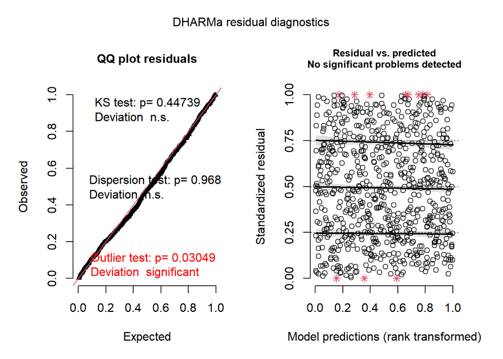

```r
latex_fixed_LMM <- glmmTMB((Latex_weight_mg)^(1/3) ~
                            Block +
                            (1|Population/Family) +
                            City_dist,
                          data = latex,
                          REML = F)

plot(DHARMa::simulateResiduals(latex_fixed_LMM)) # looks fine
```

```r
summary(latex_fixed_LMM)
```

```
##  Family: gaussian  ( identity )
## Formula:
## (Latex_weight_mg)^(1/3) ~ Block + (1 | Population/Family) + City_dist
## Data: latex
##
##      AIC      BIC   logLik deviance df.resid
##    721.2    757.6   -352.6    705.2      691
##
## Random effects:
##
## Conditional model:
##  Groups            Name        Variance Std.Dev.
##  Family:Population (Intercept) 0.007448 0.08630
##  Population        (Intercept) 0.005769 0.07595
##  Residual                      0.149459 0.38660
## Number of obs: 699, groups:  Family:Population, 197; Population, 51
##
## Dispersion estimate for gaussian family (sigma^2): 0.149
##
## Conditional model:
##               Estimate Std. Error z value Pr(>|z|)
## (Intercept)  1.9987869  0.0454702   43.96  < 2e-16 ***
## Block2       0.0004375  0.0395859    0.01   0.9912
## Block3      -0.0975621  0.0422896   -2.31   0.0211 *
## Block4      -0.1972398  0.0435194   -4.53 5.84e-06 ***
## City_dist   -0.0005930  0.0011975   -0.50   0.6204
## ---
## Signif. codes:  0 '***' 0.001 '**' 0.01 '*' 0.05 '.' 0.1 ' ' 1
```

```r
car::Anova(latex_fixed_LMM) # p = 0.62
```

```
## Analysis of Deviance Table (Type II Wald chisquare tests)
##
## Response: (Latex_weight_mg)^(1/3)
##             Chisq Df Pr(>Chisq)
## Block     27.1449  3  5.489e-06 ***
## City_dist  0.2452  1     0.6204
## ---
## Signif. codes:  0 '***' 0.001 '**' 0.01 '*' 0.05 '.' 0.1 ' ' 1
```

```r
r.squaredGLMM(latex_fixed_LMM) # R2m = 0.037
```

```
##             R2m       R2c
## [1,] 0.03730575 0.1155199
```

#### BLUP model

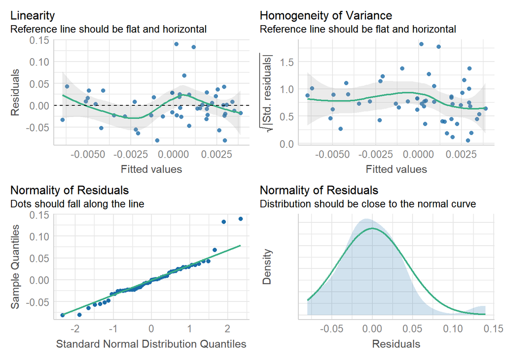

```r
latex_fixed_LMM_without_citydist <- update(
  latex_fixed_LMM,
  .~. - City_dist
)

blup_fams_latex_fixed <- ranef(
  latex_fixed_LMM_without_citydist
  )$cond[['Family:Population']] %>%
  tibble::rownames_to_column("Family_Pop") %>%
  dplyr::rename(estimate = 2)


blup_pops_latex_fixed <- ranef(
  latex_fixed_LMM_without_citydist
)$cond$Population %>%
  tibble::rownames_to_column("Population") %>%
  dplyr::rename(estimate = 2) %>%
  left_join(., latex %>% # add city_dist and other variables
              dplyr::select(c(2,18,20,22)) %>%
              dplyr::group_by(Population) %>%
              dplyr::summarise(Population = first(Population),
                               Transect_ID = first(Transect_ID),
                               City_dist = first(City_dist),
                               Urb_score = first(Urb_score)))
# simpler linear model
latex_fixed_LM <- glmmTMB(estimate ~
                            City_dist,
                          data = blup_pops_latex_fixed)

performance::check_model(latex_fixed_LM) # looks ok
```

```r
summary(latex_fixed_LM)
```

```
##  Family: gaussian  ( identity )
## Formula:          estimate ~ City_dist
## Data: blup_pops_latex_fixed
##
##      AIC      BIC   logLik deviance df.resid
##   -172.1   -166.3     89.0   -178.1       48
##
##
## Dispersion estimate for gaussian family (sigma^2): 0.00178
##
## Conditional model:
##               Estimate Std. Error z value Pr(>|z|)
## (Intercept)  0.0044918  0.0112118   0.401    0.689
## City_dist   -0.0001630  0.0003457  -0.472    0.637
```

```r
car::Anova(latex_fixed_LM) # p = 0.64
```

```
## Analysis of Deviance Table (Type II Wald chisquare tests)
##
## Response: estimate
##            Chisq Df Pr(>Chisq)
## City_dist 0.2223  1     0.6373
```

```r
r.squaredGLMM(latex_fixed_LM) # R2m about 10x smaller than LMM: R2m = 0.004
```

```
##              R2m         R2c
## [1,] 0.004426567 0.004426567
```

#### Conclusion

> Between models, p-values extremely similar yet marginal R-square value of population-level model is 10x LOWER than plant-level model (still small, though- R2m of plant-level (LMM) = 0.04).

> This suggests that my experimental design is powerful enough to detect an effect of genetic divergence due to urbanization.

> Also suggests that adding block as a fixed effect REMOVES a lot of noise from the LMM.

## Herbivory: Before flowering (binary)

### Year and Block are random

#### Original linear mixed model

```r
# first, create new column with 0/1 indicating any herbivory
herbivory %<>%
  mutate(Herbivory_mean_early_binary = case_when(
    Herbivory_mean_early == 0 ~ 0,
    Herbivory_mean_early > 0 ~ 1)
  )

herb_early_binary_random_LMM <- glmmTMB(Herbivory_mean_early_binary ~
          (1|Block) +
          (1|Year) +
          (1|Population/Family) +
          City_dist,
        data = herbivory %>%
          dplyr::filter(Year != 2019), # empty year
        family = binomial,
        REML = F)

summary(herb_early_binary_random_LMM)
```

```
##  Family: binomial  ( logit )
## Formula:
## Herbivory_mean_early_binary ~ (1 | Block) + (1 | Year) + (1 |
##     Population/Family) + City_dist
## Data: herbivory %>% dplyr::filter(Year != 2019)
##
##      AIC      BIC   logLik deviance df.resid
##   1918.6   1950.9   -953.3   1906.6     1606
##
## Random effects:
##
## Conditional model:
##  Groups            Name        Variance  Std.Dev.
##  Block             (Intercept) 9.390e-03 9.690e-02
##  Year              (Intercept) 3.943e-01 6.279e-01
##  Family:Population (Intercept) 9.713e-09 9.855e-05
##  Population        (Intercept) 1.149e-09 3.389e-05
## Number of obs: 1612, groups:
## Block, 4; Year, 2; Family:Population, 203; Population, 51
##
## Conditional model:
##              Estimate Std. Error z value Pr(>|z|)
## (Intercept)  0.990306   0.461005   2.148   0.0317 *
## City_dist   -0.006840   0.003396  -2.014   0.0440 *
## ---
## Signif. codes:  0 '***' 0.001 '**' 0.01 '*' 0.05 '.' 0.1 ' ' 1
```

```r
car::Anova(herb_early_binary_random_LMM) # p = 0.044
```

```
## Analysis of Deviance Table (Type II Wald chisquare tests)
##
## Response: Herbivory_mean_early_binary
##            Chisq Df Pr(>Chisq)
## City_dist 4.0577  1    0.04397 *
## ---
## Signif. codes:  0 '***' 0.001 '**' 0.01 '*' 0.05 '.' 0.1 ' ' 1
```

```r
r.squaredGLMM(herb_early_binary_random_LMM) # R2m = 0.002
```

```
##                     R2m        R2c
## theoretical 0.003320428 0.11225434
## delta       0.002477916 0.08377135
```

#### BLUP model

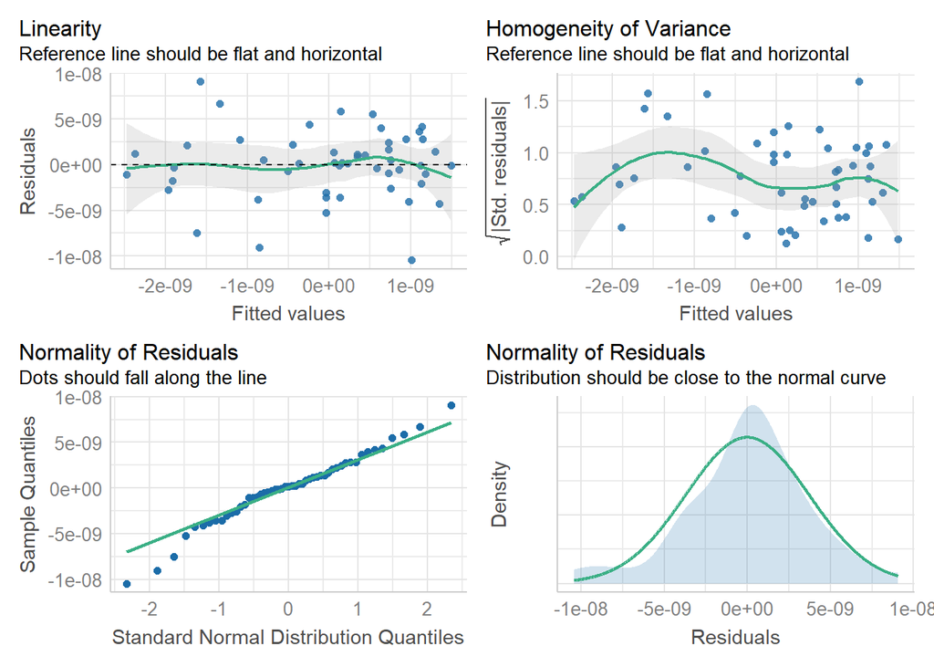

```r
herb_early_binary_random_LMM_without_citydist <- update(
  herb_early_binary_random_LMM,
  .~. - City_dist
)

blup_fams_herb_early_bin <- ranef(
  herb_early_binary_random_LMM_without_citydist
)$cond[['Family:Population']] %>%
  tibble::rownames_to_column("Family_Pop") %>%
  dplyr::rename(estimate = 2)


blup_pops_herb_early_bin <- ranef(
  herb_early_binary_random_LMM_without_citydist
)$cond$Population %>%
  tibble::rownames_to_column("Population") %>%
  dplyr::rename(estimate = 2) %>%
  left_join(., herbivory %>% # add city_dist and other variables
              dplyr::select(c(Population,
                            Transect_ID,
                            City_dist,
                            Urb_score)
                            ) %>%
              dplyr::group_by(Population) %>%
              dplyr::summarise(Population  = first(Population),
                               Transect_ID = first(Transect_ID),
                               City_dist   = first(City_dist),
                               Urb_score   = first(Urb_score)))
# simpler linear model- convergence issue
herb_early_binary_random_LM <- glmmTMB(estimate ~
                            City_dist,
                          data = blup_pops_herb_early_bin)
performance::check_model(herb_early_binary_random_LM) # looks ok
```

```r
summary(herb_early_binary_random_LM) # not working
```

```
##  Family: gaussian  ( identity )
## Formula:          estimate ~ City_dist
## Data: blup_pops_herb_early_bin
##
##      AIC      BIC   logLik deviance df.resid
##  -1830.0  -1824.2    918.0  -1836.0       48
##
##
## Dispersion estimate for gaussian family (sigma^2): 1.36e-17
##
## Conditional model:
##               Estimate Std. Error z value Pr(>|z|)
## (Intercept)  1.718e-09        NaN     NaN      NaN
## City_dist   -6.233e-11        NaN     NaN      NaN
```

```r
car::Anova(herb_early_binary_random_LM) # not working
```

```
## Analysis of Deviance Table (Type II Wald chisquare tests)
##
## Response: estimate
##           Chisq Df Pr(>Chisq)
## City_dist   NaN  1        NaN
```

```r
r.squaredGLMM(herb_early_binary_random_LM) # R2m = 0.08
```

```
##             R2m        R2c
## [1,] 0.07860103 0.07860103
```

#### Conclusion

> Also suggests that random effects add a lot of noise to the model.

### Year and Block are fixed

#### Original linear mixed model

```r
herb_early_binary_fixed_LMM <- glmmTMB(Herbivory_mean_early_binary ~
          Block +
          Year +
          (1|Population/Family) +
          City_dist,
        data = herbivory %>%
          dplyr::filter(Year != 2019), # empty year
        family = binomial,
        REML = F)

summary(herb_early_binary_fixed_LMM)
```

```
##  Family: binomial  ( logit )
## Formula:
## Herbivory_mean_early_binary ~ Block + Year + (1 | Population/Family) +
##     City_dist
## Data: herbivory %>% dplyr::filter(Year != 2019)
##
##      AIC      BIC   logLik deviance df.resid
##   1907.5   1950.6   -945.8   1891.5     1604
##
## Random effects:
##
## Conditional model:
##  Groups            Name        Variance  Std.Dev.
##  Family:Population (Intercept) 9.080e-09 9.529e-05
##  Population        (Intercept) 3.604e-10 1.898e-05
## Number of obs: 1612, groups:  Family:Population, 203; Population, 51
##
## Conditional model:
##              Estimate Std. Error z value Pr(>|z|)
## (Intercept)  1.764583   0.167824  10.515   <2e-16 ***
## Block2      -0.193823   0.157065  -1.234   0.2172
## Block3      -0.050135   0.158353  -0.317   0.7515
## Block4      -0.331331   0.158709  -2.088   0.0368 *
## Year2021    -1.263749   0.113947 -11.091   <2e-16 ***
## City_dist   -0.006777   0.003401  -1.993   0.0463 *
## ---
## Signif. codes:  0 '***' 0.001 '**' 0.01 '*' 0.05 '.' 0.1 ' ' 1
```

```r
car::Anova(herb_early_binary_fixed_LMM) # p = 0.046
```

```
## Analysis of Deviance Table (Type II Wald chisquare tests)
##
## Response: Herbivory_mean_early_binary
##              Chisq Df Pr(>Chisq)
## Block       5.3578  3    0.14740
## Year      123.0036  1    < 2e-16 ***
## City_dist   3.9701  1    0.04631 *
## ---
## Signif. codes:  0 '***' 0.001 '**' 0.01 '*' 0.05 '.' 0.1 ' ' 1
```

```r
r.squaredGLMM(herb_early_binary_fixed_LMM) # R2m = 0.086
```

```
##                    R2m        R2c
## theoretical 0.11512498 0.11512499
## delta       0.08576742 0.08576742
```

#### BLUP model

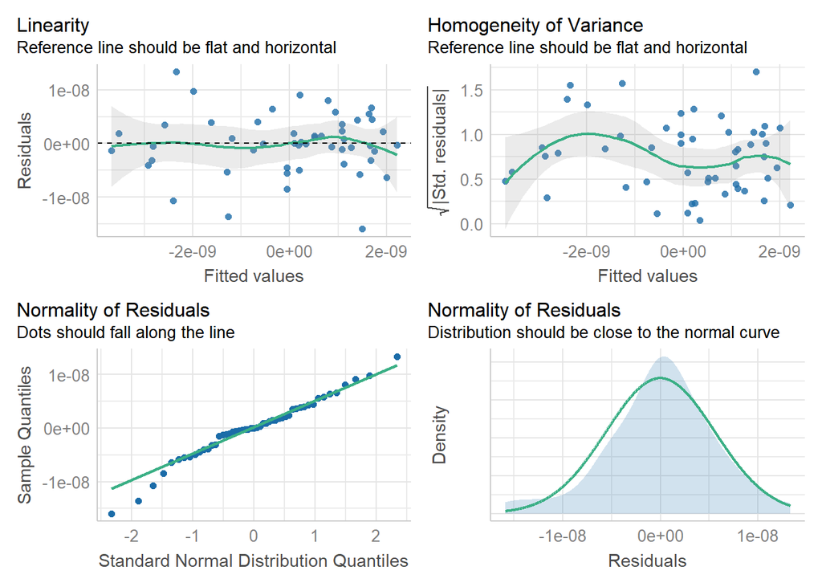

```r
herb_early_binary_fixed_LMM_without_citydist <- update(
  herb_early_binary_fixed_LMM,
  .~. - City_dist
)

blup_fams_herb_early_bin <- ranef(
  herb_early_binary_fixed_LMM_without_citydist
)$cond[['Family:Population']] %>%
  tibble::rownames_to_column("Family_Pop") %>%
  dplyr::rename(estimate = 2)


blup_pops_herb_early_bin <- ranef(
  herb_early_binary_fixed_LMM_without_citydist
)$cond$Population %>%
  tibble::rownames_to_column("Population") %>%
  dplyr::rename(estimate = 2) %>%
  left_join(., herbivory %>% # add city_dist and other variables
              dplyr::select(c(Population,
                            Transect_ID,
                            City_dist,
                            Urb_score)
                            ) %>%
              dplyr::group_by(Population) %>%
              dplyr::summarise(Population  = first(Population),
                               Transect_ID = first(Transect_ID),
                               City_dist   = first(City_dist),
                               Urb_score   = first(Urb_score)))
# simpler linear model- convergence issue
herb_early_binary_fixed_LM <- glmmTMB(estimate ~
                            City_dist,
                          data = blup_pops_herb_early_bin)
performance::check_model(herb_early_binary_fixed_LM) # looks ok
```

```r
summary(herb_early_binary_fixed_LM) # not working
```

```
##  Family: gaussian  ( identity )
## Formula:          estimate ~ City_dist
## Data: blup_pops_herb_early_bin
##
##      AIC      BIC   logLik deviance df.resid
##  -1788.9  -1783.1    897.5  -1794.9       48
##
##
## Dispersion estimate for gaussian family (sigma^2): 3.04e-17
##
## Conditional model:
##               Estimate Std. Error z value Pr(>|z|)
## (Intercept)  2.554e-09        NaN     NaN      NaN
## City_dist   -9.268e-11        NaN     NaN      NaN
```

```r
car::Anova(herb_early_binary_fixed_LM) # not working
```

```
## Analysis of Deviance Table (Type II Wald chisquare tests)
##
## Response: estimate
##           Chisq Df Pr(>Chisq)
## City_dist   NaN  1        NaN
```

```r
r.squaredGLMM(herb_early_binary_fixed_LM) # R2m = 0.077
```

```
##            R2m       R2c
## [1,] 0.0777834 0.0777834
```

#### Conclusion

> Also suggests that adding block and year as a fixed effects removes some noise from the LMM.

## Herbivory: After flowering (binary)

### Year and Block are random

#### Original linear mixed model

```r
# first, create new column with 0/1 indicating any herbivory
herbivory %<>%
  mutate(Herbivory_mean_late_binary = case_when(
    Herbivory_mean_late == 0 ~ 0,
    Herbivory_mean_late > 0 ~ 1)
  )

herb_late_binary_random_LMM <- glmmTMB(Herbivory_mean_late_binary ~
          (1|Block) +
          (1|Year) +
          (1|Population/Family) +
          City_dist,
        data = herbivory %>%
          dplyr::filter(Year != "2019"),
        family = binomial,
        REML = F)

summary(herb_late_binary_random_LMM)
```

```
##  Family: binomial  ( logit )
## Formula:          Herbivory_mean_late_binary ~ (1 | Block) + (1 | Year) + (1 |
##     Population/Family) + City_dist
## Data: herbivory %>% dplyr::filter(Year != "2019")
##
##      AIC      BIC   logLik deviance df.resid
##    731.9    763.8   -359.9    719.9     1494
##
## Random effects:
##
## Conditional model:
##  Groups            Name        Variance  Std.Dev.
##  Block             (Intercept) 2.125e-01 4.609e-01
##  Year              (Intercept) 2.558e-01 5.058e-01
##  Family:Population (Intercept) 3.717e-02 1.928e-01
##  Population        (Intercept) 2.653e-09 5.151e-05
## Number of obs: 1500, groups:
## Block, 4; Year, 2; Family:Population, 205; Population, 51
##
## Conditional model:
##             Estimate Std. Error z value Pr(>|z|)
## (Intercept) 2.693259   0.485473   5.548 2.89e-08 ***
## City_dist   0.004279   0.006587   0.650    0.516
## ---
## Signif. codes:  0 '***' 0.001 '**' 0.01 '*' 0.05 '.' 0.1 ' ' 1
```

```r
car::Anova(herb_late_binary_random_LMM) # p = 0.52
```

```
## Analysis of Deviance Table (Type II Wald chisquare tests)
##
## Response: Herbivory_mean_late_binary
##           Chisq Df Pr(>Chisq)
## City_dist 0.422  1      0.516
```

```r
r.squaredGLMM(herb_late_binary_random_LMM) # R2m = 0.0002
```

```
##                     R2m        R2c
## theoretical 0.001251380 0.13425564
## delta       0.000295516 0.03170477
```

#### BLUP model

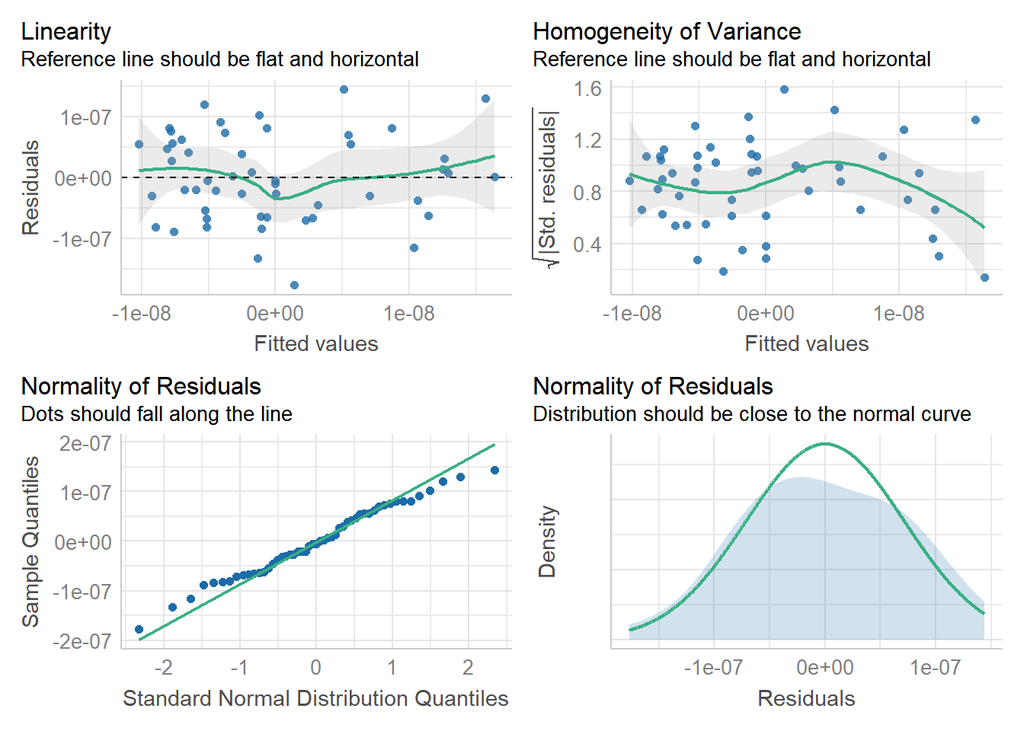

```r
herb_late_binary_random_LMM_without_citydist <- update(
  herb_late_binary_random_LMM,
  .~. - City_dist
)

blup_fams_herb_late_bin <- ranef(
  herb_late_binary_random_LMM_without_citydist
)$cond[['Family:Population']] %>%
  tibble::rownames_to_column("Family_Pop") %>%
  dplyr::rename(estimate = 2)


blup_pops_herb_late_bin <- ranef(
  herb_late_binary_random_LMM_without_citydist
)$cond$Population %>%
  tibble::rownames_to_column("Population") %>%
  dplyr::rename(estimate = 2) %>%
  left_join(., herbivory %>% # add city_dist and other variables
              dplyr::select(c(Population,
                            Transect_ID,
                            City_dist,
                            Urb_score)
                            ) %>%
              dplyr::group_by(Population) %>%
              dplyr::summarise(Population  = first(Population),
                               Transect_ID = first(Transect_ID),
                               City_dist   = first(City_dist),
                               Urb_score   = first(Urb_score)))
# simpler linear model- convergence issue
herb_late_binary_random_LM <- glmmTMB(estimate ~
                            City_dist,
                          data = blup_pops_herb_late_bin)
performance::check_model(herb_late_binary_random_LM) # looks ok
```

```r
summary(herb_late_binary_random_LM) # not working
```

```
##  Family: gaussian  ( identity )
## Formula:          estimate ~ City_dist
## Data: blup_pops_herb_late_bin
##
##      AIC      BIC   logLik deviance df.resid
##  -1528.6  -1522.8    767.3  -1534.6       48
##
##
## Dispersion estimate for gaussian family (sigma^2): 5.01e-15
##
## Conditional model:
##               Estimate Std. Error z value Pr(>|z|)
## (Intercept) -1.177e-08        NaN     NaN      NaN
## City_dist    4.185e-10        NaN     NaN      NaN
```

```r
car::Anova(herb_late_binary_random_LM) # not working
```

```
## Analysis of Deviance Table (Type II Wald chisquare tests)
##
## Response: estimate
##           Chisq Df Pr(>Chisq)
## City_dist   NaN  1        NaN
```

```r
r.squaredGLMM(herb_late_binary_random_LM) # R2m = 0.01
```

```
##             R2m        R2c
## [1,] 0.01032074 0.01032074
```

#### Conclusion

> Between models, can’t compare p-values due to convergence issues. Marginal R-square value of population-level model is ~50x higher than plant-level model (R2m(LM) = 0.01).

> Suggests that random effects add a lot of noise to the model.

### Year and Block are fixed

#### Original linear mixed model

```r
herb_late_binary_fixed_LMM <- glmmTMB(Herbivory_mean_late_binary ~
          Block +
          Year +
          (1|Population/Family) +
          City_dist,
        data = herbivory %>%
          dplyr::filter(Year != "2019"),
        family = binomial,
        REML = F)

summary(herb_late_binary_fixed_LMM)
```

```
##  Family: binomial  ( logit )
## Formula:
## Herbivory_mean_late_binary ~ Block + Year + (1 | Population/Family) +
##     City_dist
## Data: herbivory %>% dplyr::filter(Year != "2019")
##
##      AIC      BIC   logLik deviance df.resid
##    720.5    763.0   -352.2    704.5     1492
##
## Random effects:
##
## Conditional model:
##  Groups            Name        Variance  Std.Dev.
##  Family:Population (Intercept) 9.272e-02 3.045e-01
##  Population        (Intercept) 3.772e-09 6.142e-05
## Number of obs: 1500, groups:  Family:Population, 205; Population, 51
##
## Conditional model:
##              Estimate Std. Error z value Pr(>|z|)
## (Intercept)  2.507977   0.333454   7.521 5.43e-14 ***
## Block2       0.257174   0.353599   0.727  0.46704
## Block3      -0.361094   0.309660  -1.166  0.24357
## Block4      -0.959247   0.295156  -3.250  0.00115 **
## Year2021     0.977279   0.238933   4.090 4.31e-05 ***
## City_dist    0.004489   0.006719   0.668  0.50411
## ---
## Signif. codes:  0 '***' 0.001 '**' 0.01 '*' 0.05 '.' 0.1 ' ' 1
```

```r
car::Anova(herb_late_binary_fixed_LMM) # p = 0.504
```

```
## Analysis of Deviance Table (Type II Wald chisquare tests)
##
## Response: Herbivory_mean_late_binary
##             Chisq Df Pr(>Chisq)
## Block     18.9552  3  0.0002793 ***
## Year      16.7296  1   4.31e-05 ***
## City_dist  0.4463  1  0.5041115
## ---
## Signif. codes:  0 '***' 0.001 '**' 0.01 '*' 0.05 '.' 0.1 ' ' 1
```

```r
r.squaredGLMM(herb_late_binary_fixed_LMM) # R2m = 0.028
```

```
##                    R2m        R2c
## theoretical 0.12008585 0.14420589
## delta       0.02826375 0.03394071
```

#### BLUP model

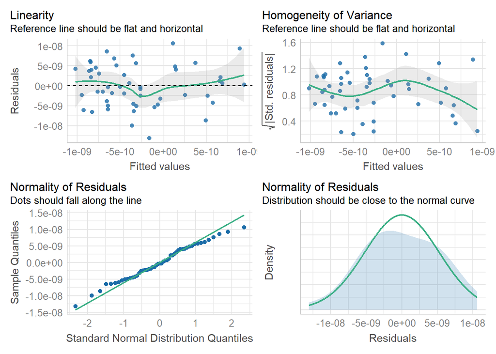

```r
herb_late_binary_fixed_LMM_without_citydist <- update(
  herb_late_binary_fixed_LMM,
  .~. - City_dist
)

blup_fams_herb_late_bin <- ranef(
  herb_late_binary_fixed_LMM_without_citydist
)$cond[['Family:Population']] %>%
  tibble::rownames_to_column("Family_Pop") %>%
  dplyr::rename(estimate = 2)


blup_pops_herb_late_bin <- ranef(
  herb_late_binary_fixed_LMM_without_citydist
)$cond$Population %>%
  tibble::rownames_to_column("Population") %>%
  dplyr::rename(estimate = 2) %>%
  left_join(., herbivory %>% # add city_dist and other variables
              dplyr::select(c(Population,
                            Transect_ID,
                            City_dist,
                            Urb_score)
                            ) %>%
              dplyr::group_by(Population) %>%
              dplyr::summarise(Population  = first(Population),
                               Transect_ID = first(Transect_ID),
                               City_dist   = first(City_dist),
                               Urb_score   = first(Urb_score)))
# simpler linear model- convergence issue
herb_late_binary_fixed_LM <- glmmTMB(estimate ~
                            City_dist,
                          data = blup_pops_herb_late_bin)
performance::check_model(herb_late_binary_fixed_LM) # looks ok
```

```r
summary(herb_late_binary_fixed_LM) # not working
```

```
##  Family: gaussian  ( identity )
## Formula:          estimate ~ City_dist
## Data: blup_pops_herb_late_bin
##
##      AIC      BIC   logLik deviance df.resid
##  -1794.9  -1789.1    900.5  -1800.9       48
##
##
## Dispersion estimate for gaussian family (sigma^2): 2.71e-17
##
## Conditional model:
##               Estimate Std. Error z value Pr(>|z|)
## (Intercept) -1.131e-09        NaN     NaN      NaN
## City_dist    3.076e-11        NaN     NaN      NaN
```

```r
car::Anova(herb_late_binary_fixed_LM) # not working
```

```
## Analysis of Deviance Table (Type II Wald chisquare tests)
##
## Response: estimate
##           Chisq Df Pr(>Chisq)
## City_dist   NaN  1        NaN
```

```r
r.squaredGLMM(herb_late_binary_fixed_LM) # R2m = 0.01
```

```
##             R2m        R2c
## [1,] 0.01031264 0.01031264
```

#### Conclusion

> Suggests that fixed effects remove noise from the LMM.